# STAT 413/613: Shiny Reactivity and the Server Function

Richard Ressler

2020-03-25

# 1 Learning Outcomes

- Implement basic “reactivity” within the server function in Shiny Apps.
- References
  - Chapter 4 of [Mastering Shiny](https://mastering-shiny.org/).
  - [Shiny Cheatsheet](https://github.com/rstudio/cheatsheets/blob/master/shiny.pdf).
  - Optional Resources
    - [Shiny Tutorial](https://stat545.com/shiny00_index.html).
    - [Shiny Video, Part 2](https://vimeo.com/rstudioinc/review/131218530/212d8a5a7a/#t=42m2s)
    - [Shiny Examples](https://github.com/rstudio/shiny-examples).

# 2 Intro to Reactivity in Shiny

- In Shiny, you express your server logic using reactive programming.
- Reactive programming is elegant and powerful but it can be disorienting at first
  - It’s a different approach than writing a script.
- The key idea of reactive programming is to specify a graph of dependencies so when an input changes, all related outputs are automatically updated.
- This makes the flow of an app considerably simpler, but it takes a while to get your head around how it all fits together.

# 3 The Server Function

- Recall, the server function should always look like this:

  ```r
  server <- function(input, output) {

  }
  ```

- The `input`: Argument
  - A list-like object. These are elements that you access from the UI.
  - Each element should have been created by an input function in the UI.
  - Can only be accessed in either a `render*()` function or in a `reactive()` call. E.g. the following will throw an error:

    ```r
    library(shiny)

    ui <- fluidPage(
      textInput("text", "What Text", value = "Default Text")
    )

    server <- function(input, output) {
      paste("The value text is", input$text) ## Don't do this!
    }

    shinyApp(ui = ui, server = server)
    ```

- The `output`: Argument
  - A list-like object. You modify the elements of `output` to send them to the UI.
  - You always use a `render*()` function to modify elements of `output`.
    - You’ll get an error if you don’t use a `render*()` function.

      ```r
      library(shiny)

      ui <- fluidPage(
        textOutput("text")
      )

      server <- function(input, output) {
        output$text <- "Hello World" ## Don't do this!
      }

      shinyApp(ui = ui, server = server)
      ```

# 4 Render Functions

- You’ve already seen render functions. They are of the form:

  ```r
  render*({
    ## Code goes here.
  })
  ```

- The curly braces allow you to write an expression of perhaps multiple lines of code and submit that as the argument.
- Always save output of render function as an element of the `output` list.
- Any input elements inside the `render*()` function will trigger the render code to be re-evaluated when those input elements change.
- When an input element changes, it is said to be “invalidated”. This triggers the reactive elements.
- When *any* input in a code chunk is invalidated, Shiny will rerun the *entire* code chunk (not just the portion that was invalidated).

## 4.1 **Exercise**:

- Create a Shiny App that asks for a person’s name and prints “Hello” followed by the person’s name.

# 5 Reactive Expressions

- You can create variables via `reactive()` (technically not variables but “reactive elements”). They can then be used in different `render*()` functions.

  ```r
  library(shiny)
  library(stringr)

  ui <- fluidPage(
    textInput("text", "What Text?", value = "dog"),
    textOutput("pigtext1"),
    textOutput("pigtext2")
  )

  server <- function(input, output) {

    x <- reactive({
      str_replace(input$text, "([^aeiouAEIOU]*)(.*)", "\\2\\1ay")
      # find the first non-vowel as group1 and
      # the rest of the input as group2
      # put group2 first then the group 1 consonant followed by "ay"
      })
    output$pigtext1 <- renderText(c("Original: ", input$text))
    output$pigtext2 <- renderText(c("PL Translation: ", x()))
  }

  shinyApp(ui = ui, server = server)
  ```

[figure not shown]

- The variables you create this way are called “reactive elements”.
- You can use them in `render*()` functions, but **include a “()” after them** (like function calls, because technically, they are functions).
- That is, we can define a reactive element `x` to depend upon `input$text` by

  ```r
  x <- reactive({ str_replace(input$text, "([^aeiouAEIOU]*)(.*)", "\\2\\1ay") })
  ```

  - But when we call it later, we need to call it with `()` like

    ```r
    x()
    ```

- If you didn’t use `reactive()`, you would get an error (because you would be calling `input$text` outside of a `render*()` or `reactive()` call).
- An example with simulation data

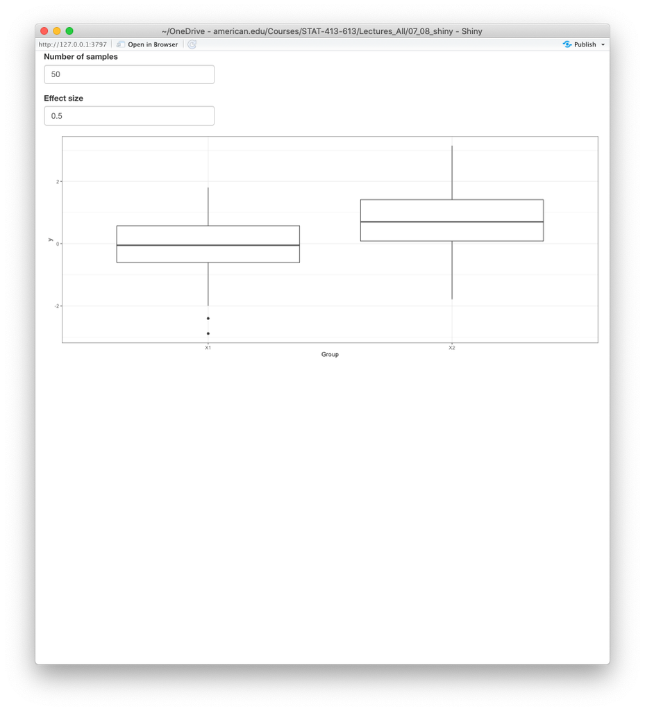

  ```r
  library(shiny)
  library(tidyverse)
  library(broom)

  ui <- fluidPage(
    numericInput("nsamp", "Number of samples", value = 50, step = 1),
    numericInput("diff", "Effect size", value = 0.5, step = 0.1),
    plotOutput("plot"),
    verbatimTextOutput("text")
  )

  server <- function(input, output) {
    x1 <- reactive({
      rnorm(n = input$nsamp, mean = 0, sd = 1)
    })

    x2 <- reactive({
      rnorm(n = input$nsamp, mean = input$diff, sd = 1)
    })

    output$plot <- renderPlot({
      data.frame(`1` = x1(), `2` = x2()) %>%
        pivot_longer(cols = everything(),names_to = "Group", values_to = "y") %>%
        ggplot(aes(x = Group, y = y)) +
        geom_boxplot() +
        theme_bw()
    })

    output$text <- renderPrint({
      t.test(x1(), x2()) %>%
        tidy() %>%
        select(estimate, `P-value` = p.value, Lower = conf.low, Higher = conf.high)
    })
  }

  shinyApp(ui = ui, server = server)
  ```

## 5.1 **Exercise**:

- Create a Shiny App that uses a slider to accept input for sample size and then simulates a sample of that size from a standard normal distribution and outputs a histogram of the data and the output of `summary()`.

# 6 More on Reactive Programming

- Shiny only runs reactive code in the server function when the inputs have changed.
- In usual R, the order of operations is defined by the order of the lines of code. This is a form of “imperative” programming.
- In Shiny, the order of operations is defined by the order of when things are needed to run. This is a form of “declarative” programming.

## 6.1 Timed Invalidation using `reactiveTimer()`

- When an input changes, Shiny calls this “invalidation” and it causes the `render*()` functions and reactive elements affected by the changed input to rerun
- You can cause invalidation in time intervals (so the reactive elements will reevaluate) using `reactiveTimer()`.
  - A crude form of animation perhaps
- `reactiveTimer()` creates a reactive element that invalidates based on a time interval.
  - The time interval argument is `intervalsMs=` for how often to fire, in milliseconds
  - To re-simulate new data every second, create a `reactiveTimer() element` and then call it in the reactive elements you wish to invalidate in timed intervals.

    ```r
    library(shiny)
    library(tidyverse)
    library(broom)

    ui <- fluidPage(
      numericInput("nsamp", "Number of samples", value = 50, step = 1),
      numericInput("diff", "Effect size", value = 0.5, step = 0.1),
      plotOutput("plot"),
      verbatimTextOutput("text")
    )

    server <- function(input, output) {
      timer1 <- reactiveTimer(1000)

      x1 <- reactive({
        timer1() #note the use of ()
        rnorm(n = input$nsamp, mean = 0, sd = 1)
      })

      x2 <- reactive({
        timer1() #note the use of ()
        rnorm(n = input$nsamp, mean = input$diff, sd = 1)
      })

      output$plot <- renderPlot({
        data.frame(`1` = x1(), `2` = x2()) %>%
          pivot_longer(cols = everything(),names_to = "Group", values_to = "y") %>%
          ggplot(aes(x = Group, y = y)) +
          geom_boxplot() +
          theme_bw()
      })

      output$text <- renderPrint({
        t.test(x1(), x2()) %>%
          tidy() %>%
          select(estimate, `P-value` = p.value, Lower = conf.low, Higher = conf.high)
      })
    }

    shinyApp(ui = ui, server = server)
    ```

### 6.1.1 **Exercise**:

Create a Shiny App that uses a slider to accept input for sample size from 1 to 200 and then simulates a sample of that size from a standard normal distribution and outputs a histogram of the data and the output of `summary()`. Make it automatically simulate new data once every **two seconds**.

## 6.2 Require the User to Click on an Action Button to initiate an Update

- If an evaluation takes a long time, you might want the user to click a button to ensure all inputs are correct before implementing it.
- Otherwise, Shiny will be trying to catch up to the changes in the inputs.
- Use an `actionButton()` in the UI along with `eventReactive()` in the server function to do this.
- `eventReactive()`:
  - Is used in place of `reactive()`.
  - Takes the `actionButton()` ID as its first argument.
  - Takes the expression to evaluate as its second argument.

[figure not shown]

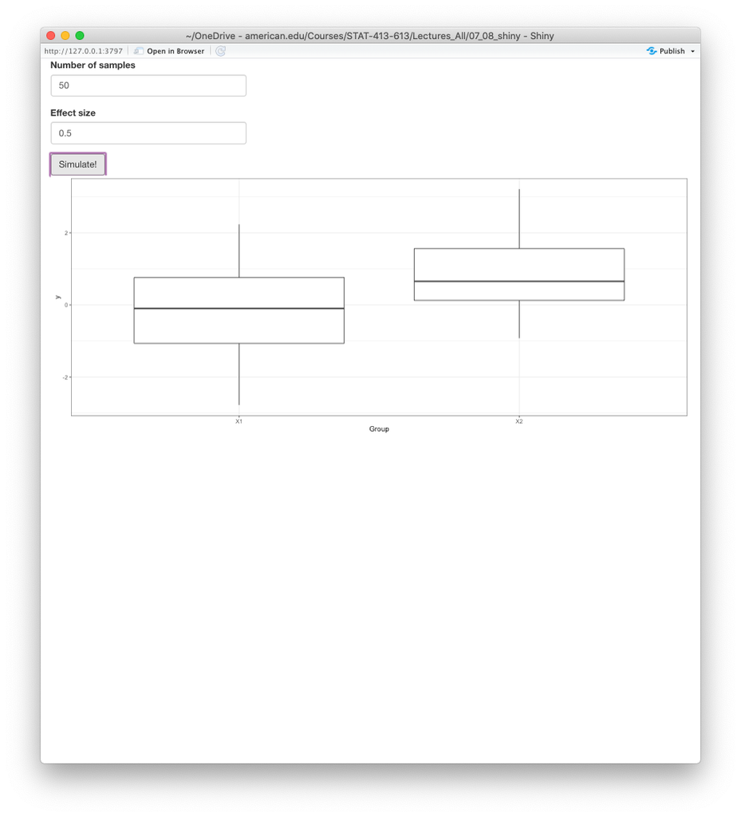

    ```r
    library(shiny)
    library(tidyverse)
    library(broom)

    ui <- fluidPage(
      numericInput("nsamp", "Number of samples", value = 50, step = 1),
      numericInput("diff", "Effect size", value = 0.5, step = 0.1),
      actionButton("simulate", "Simulate!"),
      plotOutput("plot"),
      verbatimTextOutput("text")
    )

    server <- function(input, output) {

      x1 <- eventReactive(eventExpr = input$simulate,
                          valueExpr = {
        rnorm(n = input$nsamp, mean = 0, sd = 1)
      })

      x2 <- eventReactive(eventExpr = input$simulate,
                          valueExpr = {
        rnorm(n = input$nsamp, mean = input$diff, sd = 1)
      })

      output$plot <- renderPlot({
        data.frame(`1` = x1(), `2` = x2()) %>%
          pivot_longer(cols = everything(),names_to = "Group", values_to = "y") %>%
          ggplot(aes(x = Group, y = y)) +
          geom_boxplot() +
          theme_bw()
      })

      output$text <- renderPrint({
        t.test(x1(), x2()) %>%
          tidy() %>%
          select(estimate, `P-value` = p.value, Lower = conf.low, Higher = conf.high)
      })
    }

    shinyApp(ui = ui, server = server)
    ```

### 6.2.1 **Exercise**:

- Create a Shiny App that takes as input the sample size (from 1 to 200), then simulates a sample of the input size from a standard normal distribution to output a histogram of the data and the output of `summary()`. Make it so it only updates simulated data when the user clicks an action button.

## 6.3 Observe User actions with `observeEvent()`

- Use `observeEvent()` instead of `eventReactive()` if you want to run code that does not need to be saved to some output.
  - Note: You *cannot* save the output of a call to `observeEvent()`.
- This could be saving data to a file, or printing to the console, or downloading a pre-specified file from the internet.

  ```r
  library(shiny)

  ui <- fluidPage(
    actionButton("greet", "Comfort Me")
  )

  server <- function(input, output) {
    observeEvent(input$greet,
                 {
                 print("You are loved and special!")
                 })
  }

  shinyApp(ui = ui, server = server)
  ```

## 6.4 Prevent Reactions using `isolate()`

- You can use `isolate()` to prevent inputs from invalidating outputs.

  ```r
  library(shiny)
  library(ggplot2)

  ui <- fluidPage(
    sliderInput("bins", "Bins", min = 1, max = 50, value = 20),
    textInput("title", "Title", value = "Histogram of MPG"),
    plotOutput("plot")
  )

  server <- function(input, output) {
    output$plot <- renderPlot({
      ggplot(mtcars, aes(x = mpg)) +
        geom_histogram(bins = input$bins) +
        ggtitle(isolate( {input$title} ))
    })
  }

  shinyApp(ui = ui, server = server)
  ```

- `isolate()` will prevent a chunk of code from invalidating its output object .
  - Changed input will not used for output until a different event causes the output to invalidated and rerun.
  - If other parts of the output object chunk (outside of `isolate()`) invalidate the output, then it will still use the updated input elements inside `isolate()`.
- In the example above, this means that changing the title won’t change the plot. But when we move the slider, it will update the bin width and the plot title.